# Final Exam R For Data Science

20252MBI041_Fiston_Niyigena_R

2026-11-20

### Importing Data set, as the data set and R markdown are save in the same folder no need of put full location of file

```r
library(tidyverse)
library(scales)

data <- read.csv("20252MBI041_R_For_Data_Science_Exam.csv")
```

### Data inspection and cleaning (Variable names, first five and last ten rows)

```r
names(data)
```

```
##  [1] "Country"           "happiness_score"   "gdp_per_capita"
##  [4] "family"            "health"            "freedom"
##  [7] "generosity"        "government_trust"  "dystopia_residual"
## [10] "continent"         "Year"              "social_support"
## [13] "cpi_score"
```

```r
head(data, 5)
```

```
##       Country happiness_score gdp_per_capita   family    health   freedom
## 1      Norway           7.537       1.616463 1.533524 0.7966665 0.6354226
## 2     Denmark           7.522       1.482383 1.551122 0.7925655 0.6260067
## 3     Iceland           7.504       1.480633 1.610574 0.8335521 0.6271626
## 4 Switzerland           7.494       1.564980 1.516912 0.8581313 0.6200706
## 5     Finland           7.469       1.443572 1.540247 0.8091577 0.6179509
##   generosity government_trust dystopia_residual continent Year social_support
## 1  0.3620122        0.3159638          2.277027    Europe 2015              0
## 2  0.3552805        0.4007701          2.313707    Europe 2015              0
## 3  0.4755402        0.1535266          2.322715    Europe 2015              0
## 4  0.2905493        0.3670073          2.276716    Europe 2015              0
## 5  0.2454828        0.3826115          2.430182    Europe 2015              0
##   cpi_score
## 1        88
## 2        91
## 3        79
## 4        86
## 5        90
```

```r
tail(data, 10)
```

```
##         Country happiness_score gdp_per_capita family    health   freedom
## 783      Zambia          3.7594      0.5368338      0 0.3635933 0.4913175
## 784       Haiti          3.7208      0.2847344      0 0.3743667 0.1692975
## 785       India          3.5733      0.7305762      0 0.5405701 0.5811422
## 786      Malawi          3.5380      0.1765347      0 0.4461633 0.4873898
## 787       Yemen          3.5274      0.3927018      0 0.4150002 0.2437215
## 788    Botswana          3.4789      0.9975490      0 0.4941017 0.5090894
## 789    Tanzania          3.4762      0.4571631      0 0.4426779 0.5093431
## 790      Rwanda          3.3123      0.3432427      0 0.5723833 0.6040879
## 791    Zimbabwe          3.2992      0.4255640      0 0.3750376 0.3774047
## 792 Afghanistan          2.5669      0.3007058      0 0.2660515 0.0000000
##     generosity government_trust dystopia_residual     continent Year
## 783 0.25062090      0.086705238         1.1343393        Africa 2020
## 784 0.46390966      0.161935672         1.6199169 South America 2020
## 785 0.23707248      0.105587982         0.7341309          Asia 2020
```

[output cut: 18 more lines]

### Data types and dataset shape

```r
str(data)
```

```
## 'data.frame':    792 obs. of  13 variables:
##  $ Country          : chr  "Norway" "Denmark" "Iceland" "Switzerland" ...
##  $ happiness_score  : num  7.54 7.52 7.5 7.49 7.47 ...
##  $ gdp_per_capita   : num  1.62 1.48 1.48 1.56 1.44 ...
##  $ family           : num  1.53 1.55 1.61 1.52 1.54 ...
##  $ health           : num  0.797 0.793 0.834 0.858 0.809 ...
##  $ freedom          : num  0.635 0.626 0.627 0.62 0.618 ...
##  $ generosity       : num  0.362 0.355 0.476 0.291 0.245 ...
##  $ government_trust : num  0.316 0.401 0.154 0.367 0.383 ...
##  $ dystopia_residual: num  2.28 2.31 2.32 2.28 2.43 ...
##  $ continent        : chr  "Europe" "Europe" "Europe" "Europe" ...
##  $ Year             : int  2015 2015 2015 2015 2015 2015 2015 2015 2015 2015 ...
##  $ social_support   : num  0 0 0 0 0 0 0 0 0 0 ...
##  $ cpi_score        : int  88 91 79 86 90 84 83 91 89 79 ...
```

```r
dim(data)                 # number of rows and columns
```

```
## [1] 792  13
```

```r
nrow(data)                # rows/observations
```

```
## [1] 792
```

```r
ncol(data)                # columns/variables
```

```
## [1] 13
```

### Remove duplicate rows

```r
sum(duplicated(data))
```

```
## [1] 0
```

```r
data <- data %>% distinct()
dim(data)
```

```
## [1] 792  13
```

### Missing values by column

```r
# Display missing values in each column
colSums(is.na(data))
```

```
##           Country   happiness_score    gdp_per_capita            family
##                 0                 0                 0                 0
##            health           freedom        generosity  government_trust
##                 0                 0                 0                 0
## dystopia_residual         continent              Year    social_support
##                 0                 0                 0                 0
##         cpi_score
##                 0
```

If missing values found, will be replaced. For numeric variables, we use the median, and for categorical variables, we use the most common value. If there are no missing values, no replacement is needed.

```r
# Replace missing values in numeric columns with the median
data <- data %>%
  mutate(across(where(is.numeric),
                ~ ifelse(is.na(.x), median(.x, na.rm = TRUE), .x)))

# Replace missing values in categorical columns with the most common value
mode_value <- function(x) {
  ux <- unique(x[!is.na(x)])
  ux[which.max(tabulate(match(x, ux)))]
}

data <- data %>%
  mutate(across(where(is.character),
                ~ ifelse(is.na(.x), mode_value(.x), .x)))

# Display missing values after replacement
colSums(is.na(data))
```

```
##           Country   happiness_score    gdp_per_capita            family
##                 0                 0                 0                 0
##            health           freedom        generosity  government_trust
##                 0                 0                 0                 0
## dystopia_residual         continent              Year    social_support
##                 0                 0                 0                 0
##         cpi_score
##                 0
```

### Boxplots to check quantitative-variable outliers

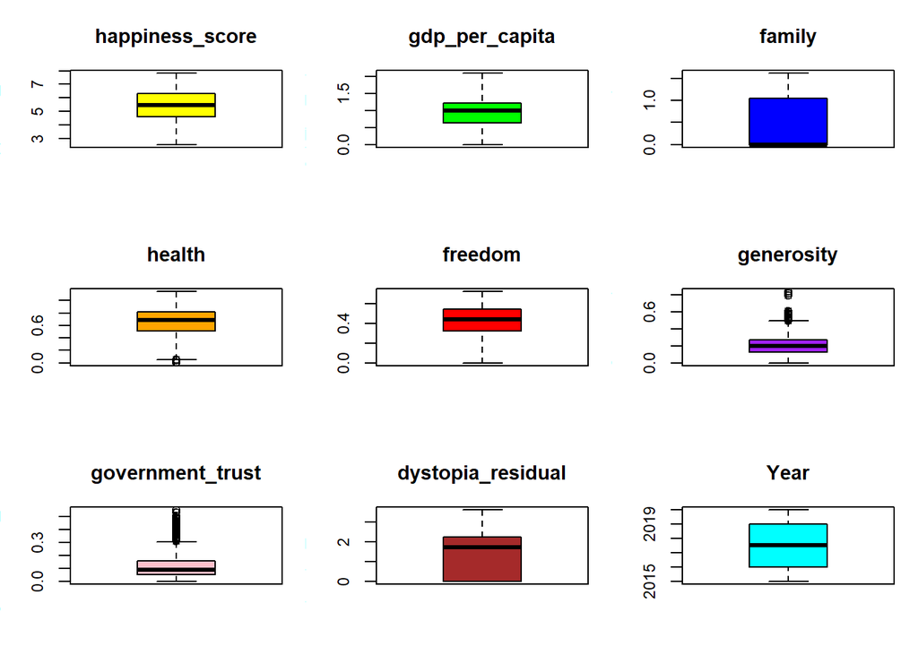

```r
# Select numeric variables
numeric_data <- data[, sapply(data, is.numeric)]

# Define different colors
box_colors <- c("yellow", "green", "blue", "orange",
                "red", "purple", "pink", "brown", "cyan")

# Display boxplots
par(mfrow = c(3, 3),
    mar = c(3, 3, 3, 1),
    cex = 0.9)

for (i in 1:ncol(numeric_data)) {
  boxplot(numeric_data[, i],
          main = names(numeric_data)[i],
          col = box_colors[i],
          border = "black",
          horizontal = FALSE,
          ylab = names(numeric_data)[i],
          cex.main = 1,
          cex.lab = 0.9,
          cex.axis = 0.8)
}
```

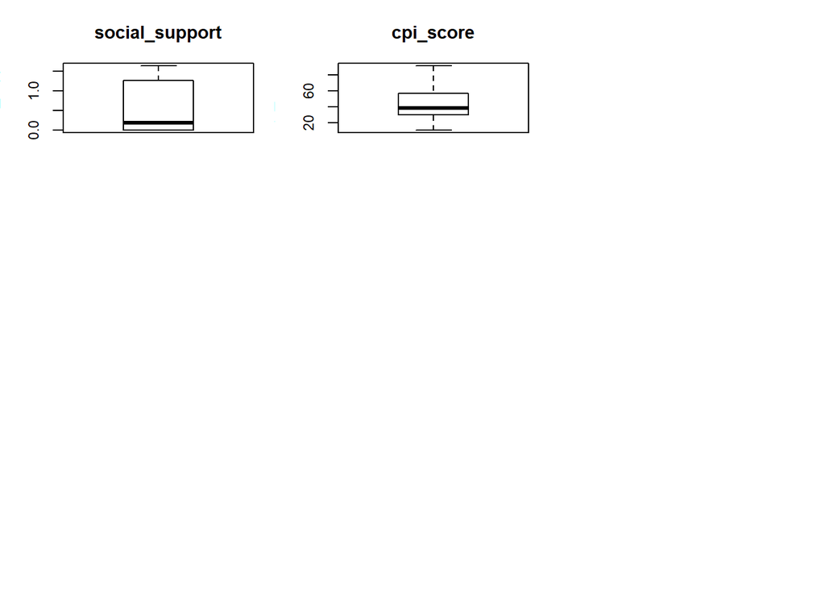

```r
# Reset the graph layout
par(mfrow = c(1, 1),
    mar = c(5, 4, 4, 2),
    cex = 1)
```

### Summaries and graphs

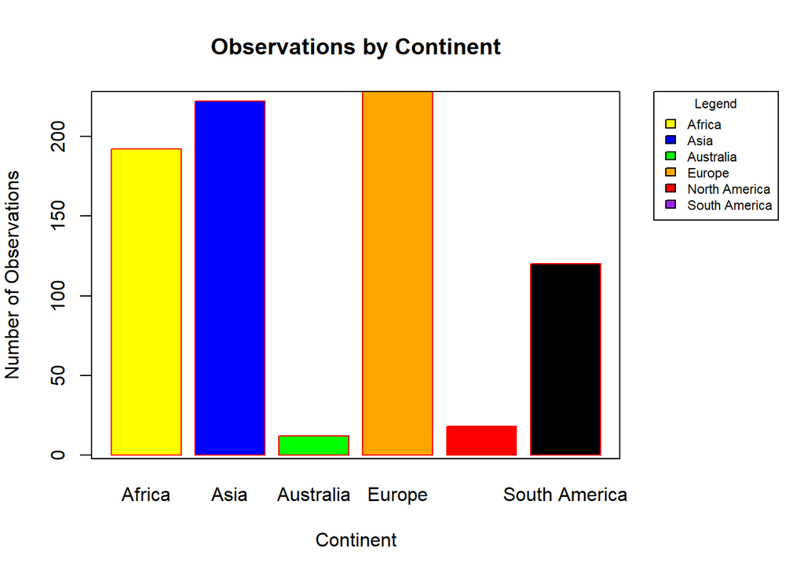

```r
# Count observations for each continent
continent_count <- table(data$continent)

# Make space for the legend
par(mar = c(5, 4, 4, 8))

# Draw the bar chart
barplot(continent_count,
        main = "Observations by Continent",
        xlab = "Continent",
        ylab = "Number of Observations",
        col = c("yellow", "blue", "green", "orange", "red", "black"),
        border = "Red")

# Add legend on the right
legend("topright",
       inset = c(-0.30, 0),
       legend = names(continent_count),
       fill = c("yellow", "blue", "green", "orange", "red", "purple"),
       title = "Legend",
       xpd = TRUE,
       cex = 0.7)

# Add a single-line frame around the graph
box()
```

```r
# Restore margins
par(mar = c(5, 4, 4, 4))
```

### Observations by year

```r
# Count observations for each year
year_count <- table(data$Year)
year_count
```

```
##
## 2015 2016 2017 2018 2019 2020
##  132  132  132  132  132  132
```

```r
# Display total observations
sum(year_count)
```

```
## [1] 792
```

```r
# Check whether observations are equal across years
year_count == 132
```

```
##
## 2015 2016 2017 2018 2019 2020
## TRUE TRUE TRUE TRUE TRUE TRUE
```

```r
# Count observations for each year
table(data$Year)
```

```
##
## 2015 2016 2017 2018 2019 2020
##  132  132  132  132  132  132
```

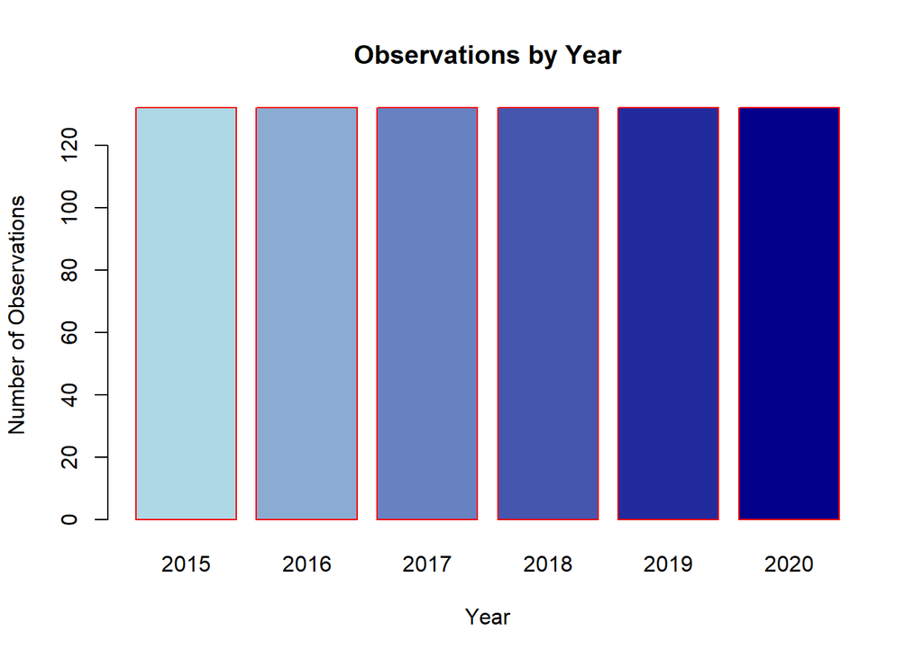

```r
# Draw a bar chart
barplot(table(data$Year),
        main = "Observations by Year",
        xlab = "Year",
        ylab = "Number of Observations",
        col = colorRampPalette(c("lightblue", "darkblue"))(6),
        border = "red")
```

#### The bars are approximately equal in height, it means the dataset contains a similar number of observations for each year.

### Happiness-score summary and distribution

```r
# Summary of happiness scores
summary(data$happiness_score)
```

```
##    Min. 1st Qu.  Median    Mean 3rd Qu.    Max.
##   2.567   4.591   5.486   5.473   6.301   7.809
```

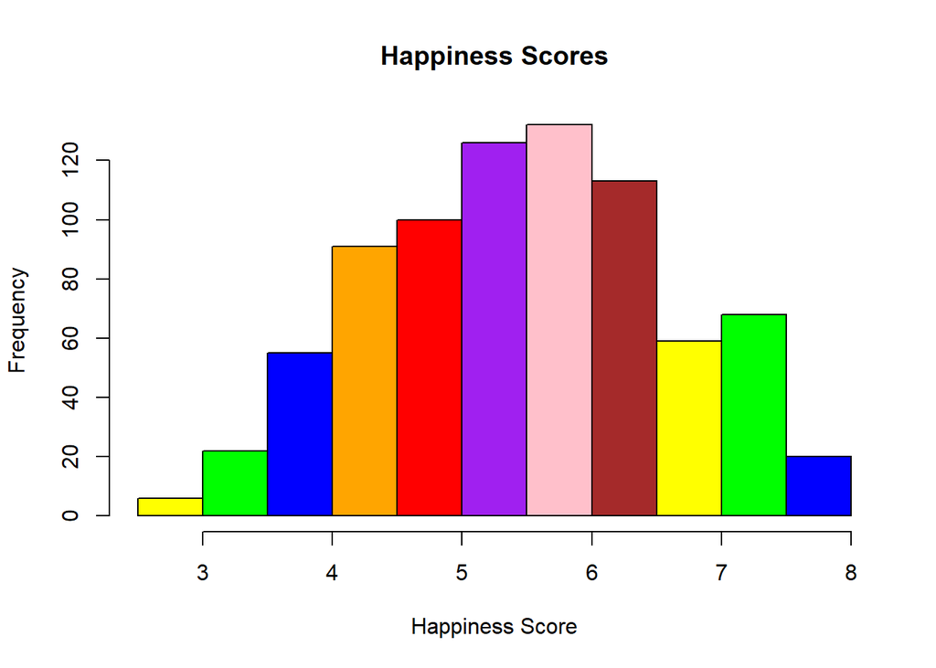

```r
# Draw a histogram
hist(data$happiness_score,
     main = "Happiness Scores",
     xlab = "Happiness Score",
     ylab = "Frequency",
     col = c("yellow", "green", "blue", "orange", "red", "purple", "pink", "brown"),
     border = "black")
```

### CPI-score summary and distribution

```r
# Summary of CPI scores
summary(data$cpi_score)
```

```
##    Min. 1st Qu.  Median    Mean 3rd Qu.    Max.
##   11.00   30.00   38.00   44.33   57.00   91.00
```

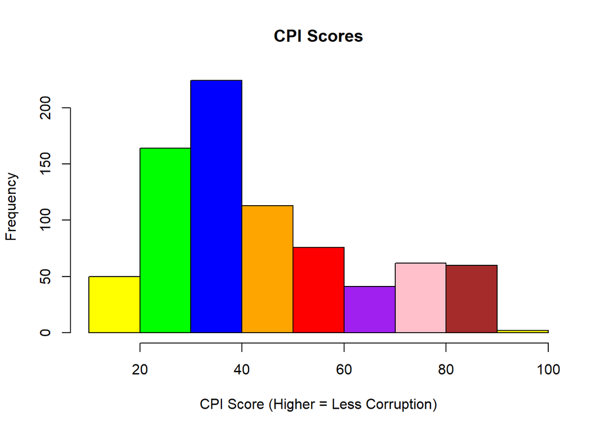

```r
# Draw a histogram
hist(data$cpi_score,
     main = "CPI Scores",
     xlab = "CPI Score (Higher = Less Corruption)",
     ylab = "Frequency",
     col = c("yellow", "green", "blue", "orange", "red", "purple", "pink", "brown"),
     border = "black")
```

### GDP per capita summary and distribution

```r
# Summary of GDP per capita
summary(data$gdp_per_capita)
```

```
##    Min. 1st Qu.  Median    Mean 3rd Qu.    Max.
##  0.0000  0.6442  0.9945  0.9292  1.2287  2.0960
```

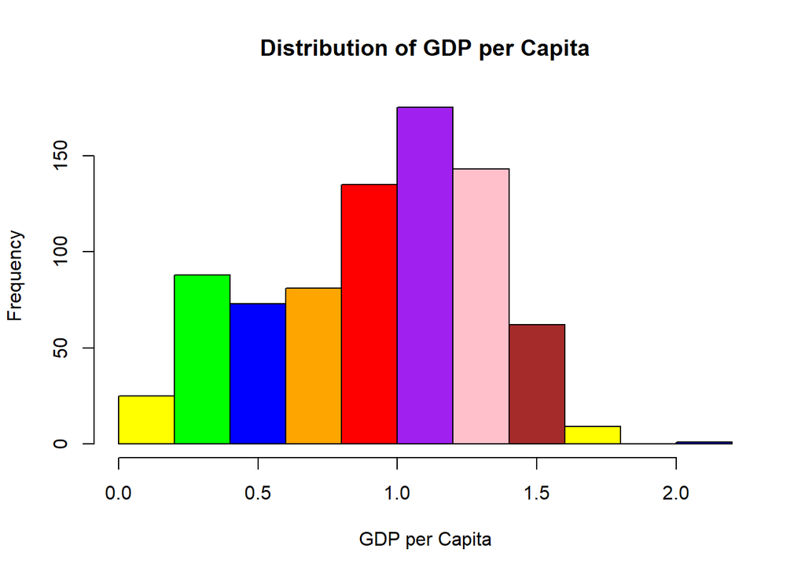

```r
# Draw a histogram
hist(data$gdp_per_capita,
     main = "Distribution of GDP per Capita",
     xlab = "GDP per Capita",
     ylab = "Frequency",
     col = c("yellow", "green", "blue", "orange", "red", "purple", "pink", "brown"),
     border = "black")
```

### Fill in the exam statement using calculations

```r
# Percentage of observations from Europe
europe_percent <- sum(data$continent == "Europe") / nrow(data) * 100

# Count observations with CPI score of 50 or above
cpi_50_count <- sum(data$cpi_score >= 50)

# Average happiness in Europe
europe_mean <- mean(data$happiness_score[data$continent == "Europe"])

# Average happiness in Africa
africa_mean <- mean(data$happiness_score[data$continent == "Africa"])

# Compare Europe's happiness with Africa's
europe_africa_ratio <- europe_mean / africa_mean

# Average happiness in 2015
mean_2015 <- mean(data$happiness_score[data$Year == 2015])

# Average happiness in 2020
mean_2020 <- mean(data$happiness_score[data$Year == 2020])

# Display results
europe_percent
```

```
## [1] 28.78788
```

```r
cpi_50_count
```

```
## [1] 248
```

```r
europe_mean
```

```
## [1] 6.193717
```

```r
africa_mean
```

```
## [1] 4.353944
```

```r
europe_africa_ratio
```

```
## [1] 1.422553
```

```r
mean_2015
```

```
## [1] 5.437485
```

```r
mean_2020
```

```
## [1] 5.559882
```

### Missing information in the statement:

The EDA shows that 28.79% of observations come from European countries. Moreover, 248 out of all country-year observations have a CPI score of 50 or above. In addition, the average happiness score of Europe is 1.42 times the average happiness score of Africa. Generally, the global average happiness score moved from 5.437 in 2015 to 5.56 in 2020.

### Happiness over time

```r
# Average happiness by year
year_happiness <- tapply(data$happiness_score, data$Year, mean)

# Display results
year_happiness
```

```
##     2015     2016     2017     2018     2019     2020
## 5.437485 5.440242 5.506848 5.464697 5.430705 5.559882
```

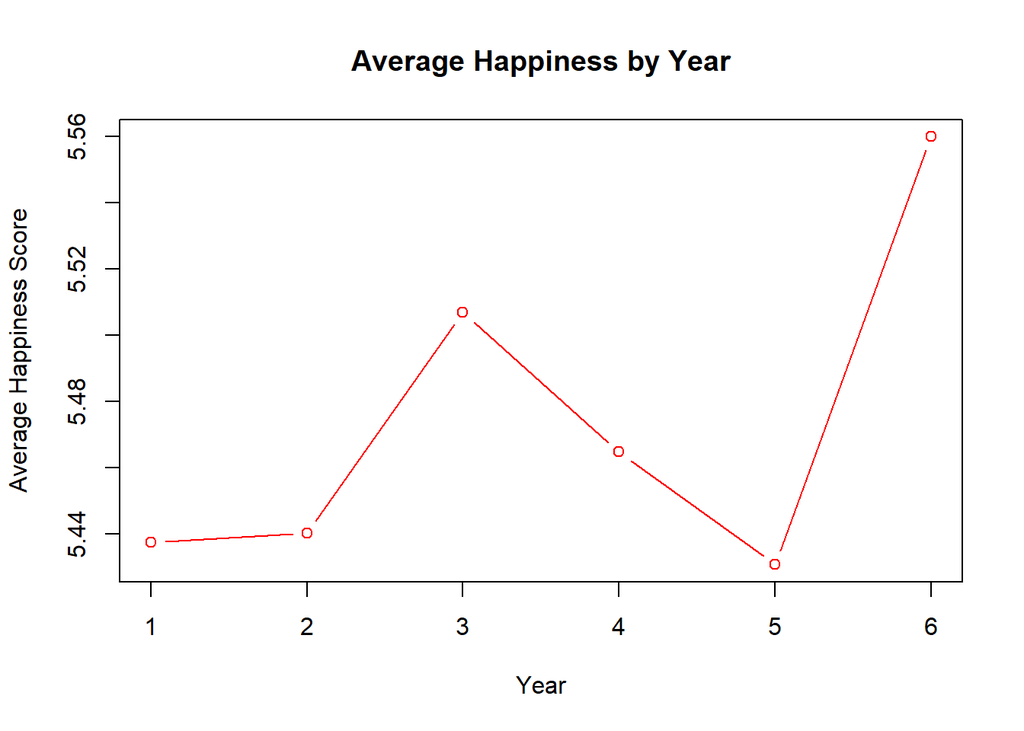

```r
# Draw a line graph
plot(year_happiness,
     type = "b",
     main = "Average Happiness by Year",
     xlab = "Year",
     ylab = "Average Happiness Score",
     col = "Red")
```

### Happiness by CPI intervals (10-point groups)

```r
# Divide CPI scores into groups of 10
data$cpi_group <- cut(data$cpi_score,
                     breaks = seq(0, 100, 10),
                     labels = c("0-9", "10-19", "20-29", "30-39",
                                "40-49", "50-59", "60-69", "70-79",
                                "80-89", "90-99"),
                     right = FALSE)

# Calculate average happiness for each CPI group
tapply(data$happiness_score, data$cpi_group, mean)
```

```
##      0-9    10-19    20-29    30-39    40-49    50-59    60-69    70-79
##       NA 4.477338 4.848955 5.130317 5.214940 5.732113 5.953291 6.762489
##    80-89    90-99
## 7.242137 7.423600
```

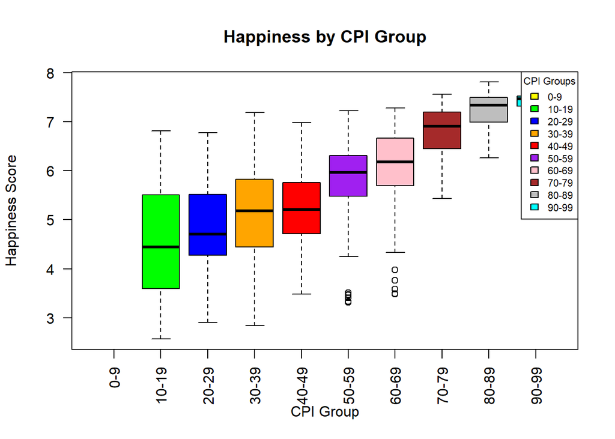

```r
# Define colors
cpi_colors <- c("yellow", "green", "blue", "orange", "red",
                "purple", "pink", "brown", "gray", "cyan")

# Draw boxplots
boxplot(happiness_score ~ cpi_group,
        data = data,
        main = "Happiness by CPI Group",
        xlab = "CPI Group",
        ylab = "Happiness Score",
        col = cpi_colors,
        las = 2)

# Add legend
legend("topright",
       legend = levels(data$cpi_group),
       fill = cpi_colors,
       title = "CPI Groups",
       cex = 0.7)
```

### CPI and happiness: scatter plot and correlation

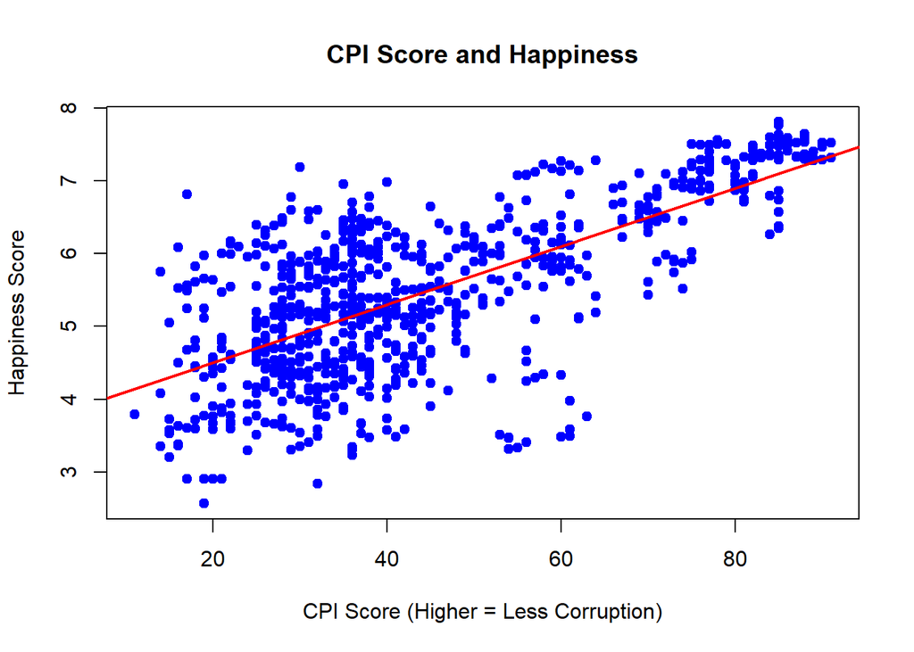

```r
# Draw a scatter plot
plot(data$cpi_score, data$happiness_score,
     main = "CPI Score and Happiness",
     xlab = "CPI Score (Higher = Less Corruption)",
     ylab = "Happiness Score",
     pch = 19,
     col = "blue")

# Add a regression line
abline(lm(happiness_score ~ cpi_score, data = data),
       col = "red",
       lwd = 2)
```

```r
# Calculate correlation
cor(data$cpi_score, data$happiness_score)
```

```
## [1] 0.6930014
```

The correlation coefficient ranges from -1 to +1. A positive correlation means that higher CPI scores are generally associated with higher happiness scores. However, correlation does not mean causation.

### Strongly correlated with happiness?

```r
# Happiness determinants
determinants <- c("gdp_per_capita", "family", "health",
                  "freedom", "generosity", "government_trust")

# Calculate correlation with happiness
correlations <- numeric(length(determinants))

for (i in 1:length(determinants)) {
  correlations[i] <- cor(data[[determinants[i]]],
                         data$happiness_score)
}

# Display correlations
correlations
```

```
## [1] 0.7932672 0.1549461 0.7535343 0.5442844 0.1554191 0.4554775
```

```r
names(correlations) <- determinants

# Sort from highest to lowest
sort(correlations, decreasing = TRUE)
```

```
##   gdp_per_capita           health          freedom government_trust
##        0.7932672        0.7535343        0.5442844        0.4554775
##       generosity           family
##        0.1554191        0.1549461
```

```r
# Find the most correlated determinant
determinants[which.max(correlations)]
```

```
## [1] "gdp_per_capita"
```

### Identifying low happiness level

```r
# Select African countries with CPI scores below 30
low_group <- data[data$continent == "Africa" & data$cpi_score < 30, ]

# List the countries in this group
unique(low_group$Country)
```

```
##  [1] "Libya"        "Nigeria"      "Sierra Leone" "Cameroon"     "Kenya"
##  [6] "Uganda"       "Chad"         "Zimbabwe"     "Madagascar"   "Burundi"
## [11] "Mauritania"   "Mali"         "Liberia"      "Togo"
```

```r
# Count observations in the group
nrow(low_group)
```

```
## [1] 64
```

```r
# Calculate average happiness of the group
group_mean <- mean(low_group$happiness_score)

# Calculate global average happiness
global_mean <- mean(data$happiness_score)

# Display the averages
group_mean
```

```
## [1] 4.301927
```

```r
global_mean
```

```
## [1] 5.47331
```

```r
# Compare the group with the global average
group_mean - global_mean
```

```
## [1] -1.171383
```

```r
# Calculate average happiness for each country
country_mean <- tapply(data$happiness_score, data$Country, mean)

# Sort countries from lowest to highest happiness
sort(country_mean)
```

```
##                Burundi            Afghanistan                 Rwanda
##               3.195050               3.355150               3.417550
##               Tanzania                  Yemen                   Togo
##               3.467700               3.609400               3.651367
##               Botswana             Madagascar                 Malawi
##               3.771483               3.815433               3.825500
##                  Haiti               Zimbabwe                Liberia
##               3.841467               3.888700               3.958983
##                 Guinea                   Chad                 Uganda
##               4.036217               4.073283               4.088833
##                  Benin                  India           Burkina Faso
##               4.120167               4.177050               4.189617
##                  Niger                   Mali               Cambodia
##               4.238767               4.304050               4.312567
##                  Egypt                Ukraine             Mauritania
##               4.337900               4.349450               4.358267
##                Myanmar              Sri Lanka               Ethiopia
##               4.370500               4.381667               4.383700
##                Georgia                Armenia                 Zambia
##               4.394433               4.440467               4.446900
##           Sierra Leone                  Kenya                  Gabon
##               4.453733               4.471667               4.478050
##                Senegal                   Iraq             Bangladesh
##               4.491800               4.571133               4.622300
##                  Ghana                Tunisia                   Iran
##               4.638333               4.672367               4.686400
##           South Africa               Bulgaria                Albania
##               4.698350               4.699083               4.740950
##               Cameroon                  Nepal                Nigeria
##               4.760650               4.866533               5.060183
##                Lebanon                 Jordan               Mongolia
##               5.086583               5.088567               5.100367
##                Morocco             Tajikistan                Vietnam
##               5.159300               5.174117               5.187750
##                  China                 Greece             Azerbaijan
##               5.203150               5.212833               5.218467
##             Kyrgyzstan Bosnia and Herzegovina              Indonesia
##               5.234750               5.247183               5.257600
##     Dominican Republic             Montenegro               Honduras
##               5.281033               5.334350               5.359533
```

[output cut: 33 more lines]

```
##               6.539967               6.573800               6.610767
##                 Mexico   United Arab Emirates                Belgium
##               6.681833               6.751967               6.911750
##         United Kingdom                Germany                Ireland
##               6.952417               6.953467               6.985950
##             Luxembourg          United States             Costa Rica
##               6.986250               6.988933               7.125400
##                 Israel                Austria              Australia
##               7.139933               7.167367               7.267300
##            New Zealand                 Sweden                 Canada
##               7.310767               7.324917               7.330850
##            Netherlands                Iceland            Switzerland
##               7.411983               7.509917               7.519483
##                 Norway                Denmark                Finland
##               7.532167               7.562600               7.582950
```

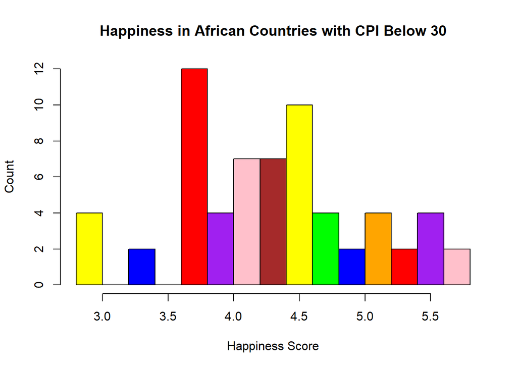

```r
hist(low_group$happiness_score,
     main = "Happiness in African Countries with CPI Below 30",
     xlab = "Happiness Score",
     ylab = "Count",
     col = c("yellow", "green", "blue", "orange", "red", "purple", "pink", "brown"),
     breaks = 15)
```

Compare the group’s average happiness with the global average. If the group’s average is lower, it means they are less happy on average than the overall population. However, this does not mean that CPI causes the difference

### Five Practical Recommendations for Policymakers

1. Improve the economy: Create jobs, support businesses and improve people’s skills to increase income and living standards.
2. Fight corruption: Promote transparency, accountability and better public services to build trust in government.
3. Improve healthcare: Provide better healthcare services, mental-health support and healthy living conditions.
4. Strengthen social support: Encourage community support, reduce inequality and help vulnerable people.
5. Protect freedom: Promote citizens’ rights, participation in decision-making and freedom to make personal choices.

### Conclusion

This analysis examines happiness across countries and over time, and how it relates to CPI and other factors. The results can help policymakers identify areas for improvement, but correlations do not prove causation.

*Acknowledgement of Lecture and AI Assistance*

I acknowledge that my lecture class activities were my main reference throughout this exam. I also used an AI tool to assist with selecting graph colors and understanding some parts of the R code. The AI assistance accounted for less than 10% of my overall work. The analysis, interpretation, and completion of the exam were primarily my own work, based mainly on the lecture class activities.